# Nutrient and chlorophyll analysis

Rosemary Hartman

2022-09-23

## Nutrients and chlorophyll

This is the nutrient and chlorophyll analysis for the Drought paper. It pulls the data that Dave organized in the Drought Data package.

First I replaced values below the reporting limit with draws from a uniform distribution, then I averaged by season, region, and year. Then I log-transformed. Sam said he thought log-transforming the mean was better than taking the mean of log-transformed data, and I trust Sam more than me.

### Amonia

I’m going to start with Ammonia. My initial look at Ammonia made it seem pretty boring. I’d lean towards leaving it out of the paper, but I”ll see if including some sort of dummy variable for WWTP upgrades helps at all.

Cloern 2019 discussed a lot of Ammonia patterns: Ammonium While the silicate source to San Francisco Bay is river inflow, the ammonium source is primarily municipal wastewater (Jassby 2008). Comparison of silicate and ammonium variability provides an opportunity to explore the differing patterns of nutrients delivered by runoff and point sources. The trends of increasing ammonium were significant for most months (Fig. 6B), so I explored models to explain variability of annual mean ammonium concentration. The best-fitting simple model explained 59% of ammonium variability with two processes— Outflow and wastewater inputs of TKN (Fig. 8D). The size effects of Outflow (−1.0) and TKN loading (+0.8) were comparable (Table 4). The relationship with Outflow is nonlinear and negative, with highest ammonium concentrations during dry years and lowest during wet years (Fig. 8D). This is opposite the Outflow-silicate relationship because river inflow is a source of silicate but it dilutes wastewater-derived ammonium. The shape of nutrient-Outflow relationships can therefore give information about the relative importance of riverine and point-source inputs. Ammonium concentration in the estuary was significantly and linearly related to TKN loading (Fig. 8D), so the long-term trend of increasing ammonium concentration (Fig. 4; Table 2) can be attributed to increasing wastewater loading over time (Fig. 7E), but not to changes in Outflow and dilution.

Ammonium at the monthly scale Analyses of water-quality time series data can yield different insights into processes depending on the time scale considered. As an example, I explored regression models to identify the key drivers of ammonium variability at the monthly scale to compare against analyses at the annual scale. This was motivated by the strong monthly pattern of ammonium trends—largest increases in winter and smallest in summer (Fig. 6B), suggesting a possible influence of seasonal temperature variability. The data series included 346 monthly measurements beginning January 1987. The best fitting model described monthly ammonium variability as a function of three variables—Outflow and TKN loading (as above), and temperature. Monthly ammonium was a nonlinear and negative function of Outflow and a linear positive function of TKN loading (Fig. 9)—the same functional responses observed at the annual scale (Fig. 8D). The Outflow effect was −2.1 and the TKN-loading effect was +1.0. However, at the monthly time scale, temperature had the largest effect (−5.8) through a negative linear relationship. Thus, both annual and monthly variability of ammonium, including trends of increase over time, are associated with variability of TKN loading as a source and Outflow through its dilution effect. However, a stronger temperature effect was revealed by analyzing monthly data. This effect is not evident in analyses of the annual data because annual temperature fluctuations are small relative to the high-amplitude monthly variability (Fig. 4A). The seasonal temperature effect on ammonium concentration in the estuary is presumably a response to the near-linear relationship between nitrification rate and temperature (e.g., Sudarno et al. 2011). Highest nitrification rates during the warm season would explain the negative relationship between ammonium and temperature (Fig. 9A), the seasonal pattern of lowest ammonium concentrations during summer (Fig. 4B), and the seasonal pattern of ammonium increase over time—largest in winter and near-zero in summer (Fig. 6B). Thus, the long-term trends of ammonium increase in the estuary can be attributed to increased wastewater inputs. But the expression of increased loading is not evident in summer (Fig. 6B), implying that wastewater ammonium is nitrified in the time of transit from the wastewater source to the sampling site in the estuary during the warm, low-flow season. Direct measurements of nitrate production and travel time in the lower Sacramento River support this conclusion (Kraus et al. 2017).

```r
#replace values below the reporting limit
Ammonia <- raw_nutr_1975_2021 %>%
  # Remove NA values in DissAmmonia
  tidyr::drop_na(DissAmmonia) %>%
  # Replace <RL values with random value
  drt_replace_rl(DissAmmonia, DissAmmonia_Sign) %>%
  # Calculate seasonal-regional averages
  drt_avg_data(DissAmmonia, avg_type = "both", month_na = "relaxed") %>%
  # Add year assignments
  drt_add_yr_assign() %>%
  mutate(YearType = factor(YearType, levels = c("Critical", "Dry", "Below Normal",
                                                "Above Normal", "Wet")),
         LogAm = log(DissAmmonia))
```

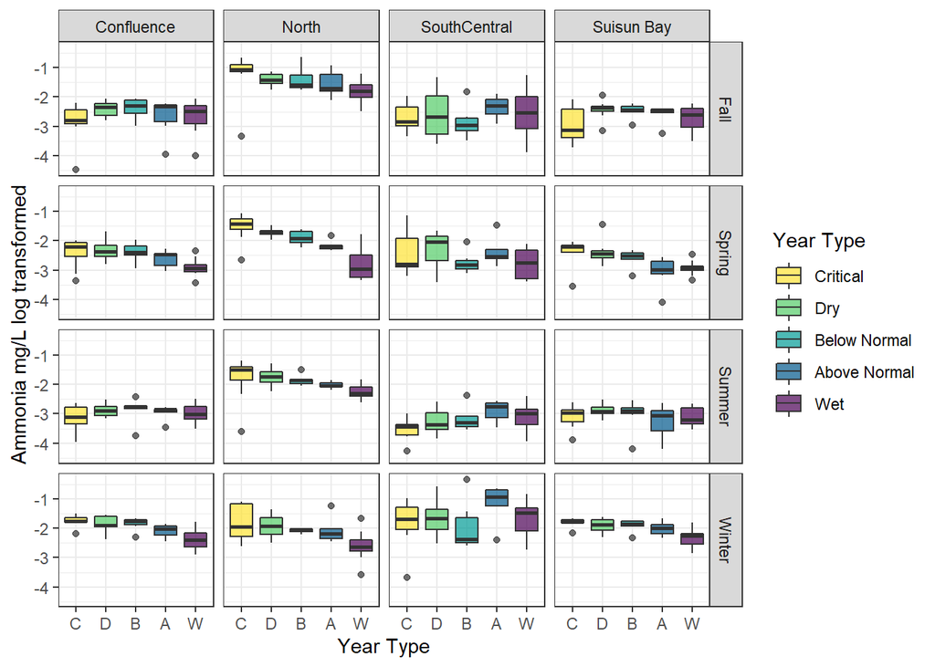

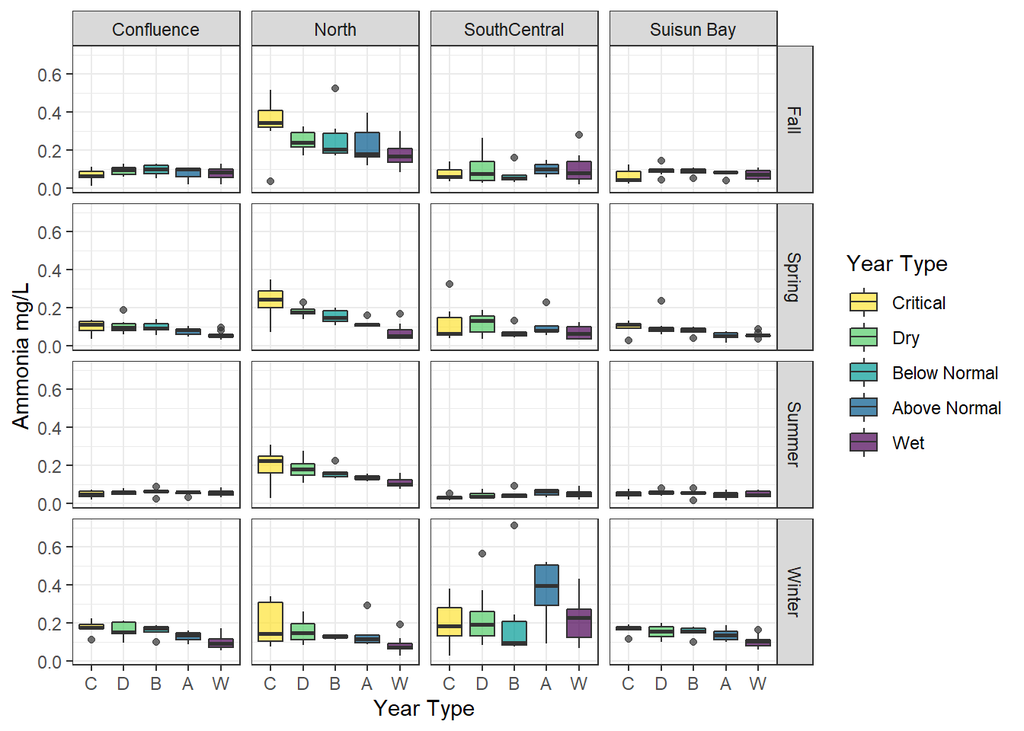

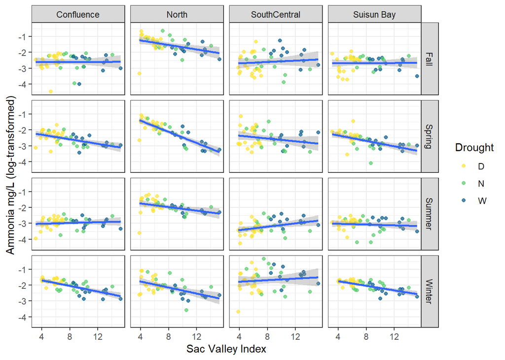

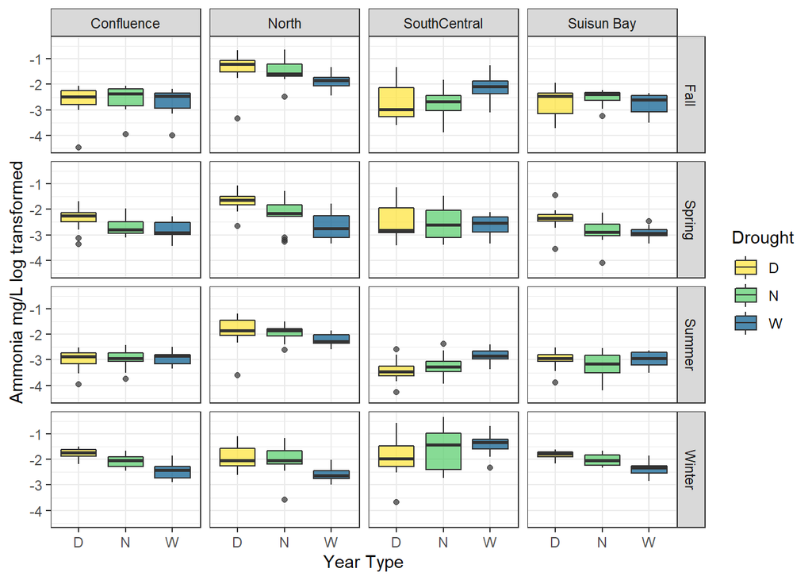

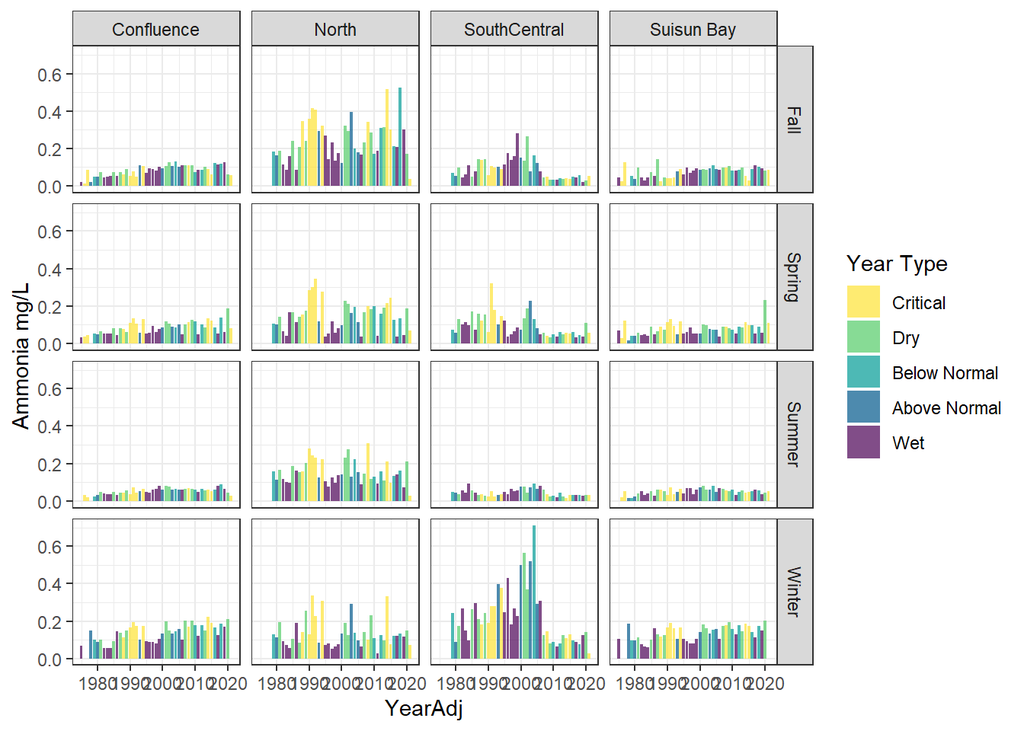

Now we’ll do the statistics. I’m going to take out 2021, because of the Sac WWTP upgrade. Stockton WWTP was upgraded in 2006

```r
Ammonia = filter(Ammonia, YearAdj < 2021) %>%
  mutate(StocktonUpgrade = case_when(YearAdj < 2006 ~ "Before",
                                     YearAdj >= 2006 ~ "After"))


Am1 = lm(LogAm ~ Drought*Region+ Drought*Season + Region*Season, data = Ammonia)
summary(Am1)
```

```
##
## Call:
## lm(formula = LogAm ~ Drought * Region + Drought * Season + Region *
##     Season, data = Ammonia)
##
## Residuals:
##      Min       1Q   Median       3Q      Max
## -1.91255 -0.24269  0.03077  0.27067  1.47669
##
## Coefficients:
##                                 Estimate Std. Error t value Pr(>|t|)
## (Intercept)                     -2.56021    0.08046 -31.818  < 2e-16 ***
## DroughtN                        -0.01760    0.10151  -0.173 0.862372
## DroughtW                        -0.11432    0.10612  -1.077 0.281741
## RegionNorth                      1.26973    0.10679  11.890  < 2e-16 ***
## RegionSouthCentral              -0.25081    0.10679  -2.349 0.019137 *
## RegionSuisun Bay                -0.08612    0.10454  -0.824 0.410343
## SeasonSpring                     0.27482    0.10486   2.621 0.008972 **
## SeasonSummer                    -0.35780    0.10514  -3.403 0.000706 ***
## SeasonWinter                     0.68317    0.10636   6.423 2.54e-10 ***
## DroughtN:RegionNorth            -0.14117    0.11003  -1.283 0.199929
## DroughtW:RegionNorth            -0.40201    0.11524  -3.488 0.000518 ***
## DroughtN:RegionSouthCentral      0.24124    0.11003   2.193 0.028689 *
## DroughtW:RegionSouthCentral      0.67790    0.11524   5.883 6.40e-09 ***
## DroughtN:RegionSuisun Bay       -0.03632    0.10823  -0.336 0.737274
## DroughtW:RegionSuisun Bay        0.04793    0.11318   0.423 0.672086
## DroughtN:SeasonSpring           -0.37314    0.10968  -3.402 0.000709 ***
## DroughtW:SeasonSpring           -0.51036    0.11446  -4.459 9.67e-06 ***
## DroughtN:SeasonSummer           -0.07444    0.10968  -0.679 0.497565
## DroughtW:SeasonSummer            0.06216    0.11529   0.539 0.589968
## DroughtN:SeasonWinter           -0.11333    0.11000  -1.030 0.303226
## DroughtW:SeasonWinter           -0.35483    0.11507  -3.084 0.002130 **
## RegionNorth:SeasonSpring        -0.63148    0.13113  -4.816 1.82e-06 ***
## RegionSouthCentral:SeasonSpring  0.04935    0.13113   0.376 0.706784
## RegionSuisun Bay:SeasonSpring   -0.02140    0.12848  -0.167 0.867785
## RegionNorth:SeasonSummer        -0.07840    0.13149  -0.596 0.551218
## RegionSouthCentral:SeasonSummer -0.24651    0.13149  -1.875 0.061269 .
## RegionSuisun Bay:SeasonSummer   -0.02062    0.12921  -0.160 0.873280
## RegionNorth:SeasonWinter        -1.20297    0.13149  -9.149  < 2e-16 ***
## RegionSouthCentral:SeasonWinter  0.40063    0.13149   3.047 0.002404 **
## RegionSuisun Bay:SeasonWinter    0.09303    0.12959   0.718 0.473107
## ---
## Signif. codes:  0 '***' 0.001 '**' 0.01 '*' 0.05 '.' 0.1 ' ' 1
##
## Residual standard error: 0.4333 on 665 degrees of freedom
##   (41 observations deleted due to missingness)
## Multiple R-squared:  0.6067, Adjusted R-squared:  0.5895
## F-statistic: 35.37 on 29 and 665 DF,  p-value: < 2.2e-16
```

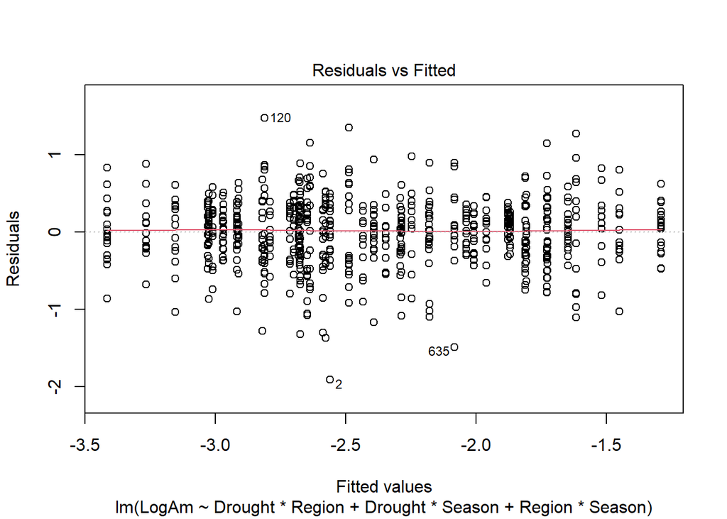

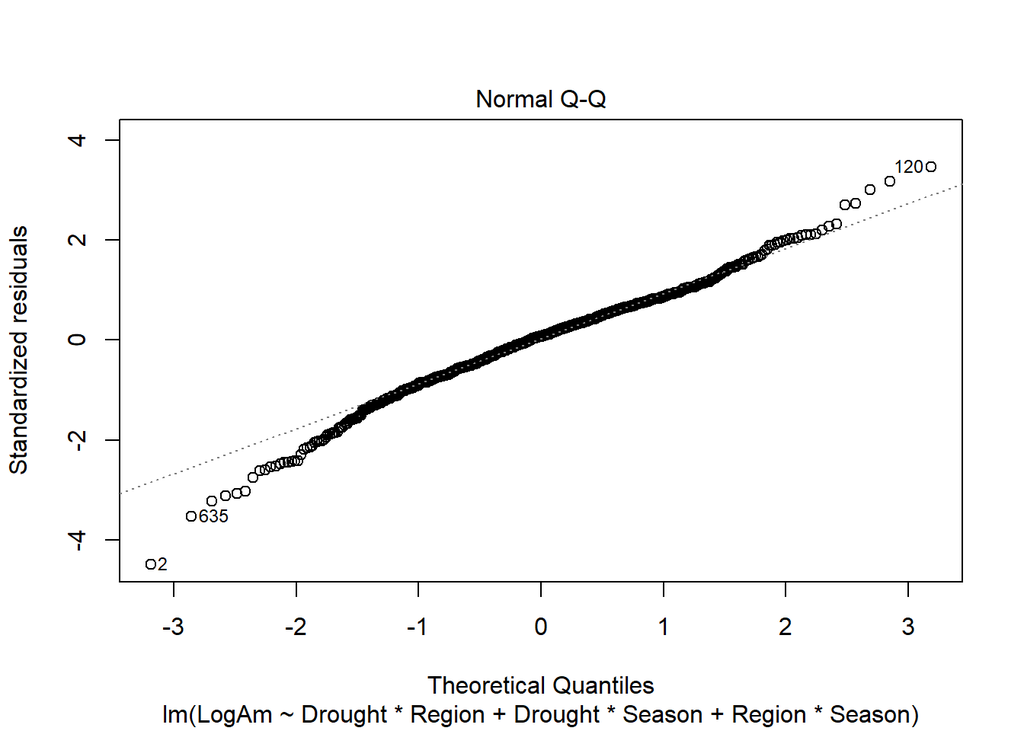

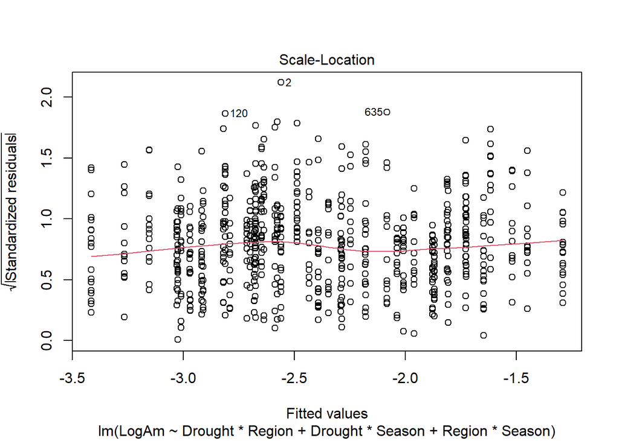

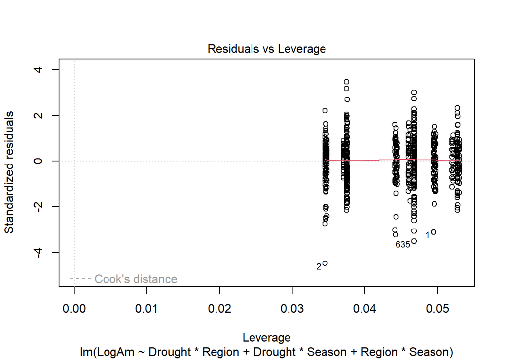

```r
plot(Am1)
```

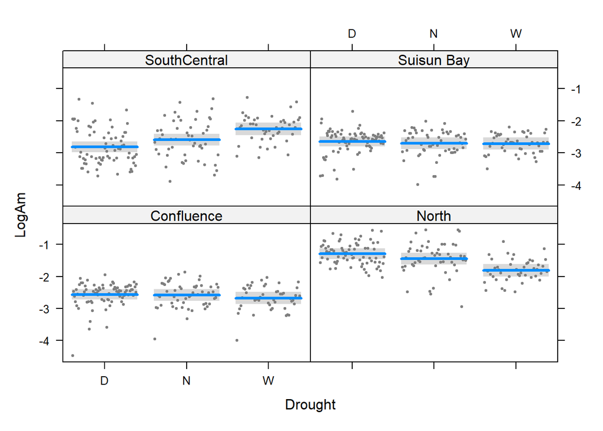

```r
visreg(Am1, xvar = "Drought", by = "Region")
```

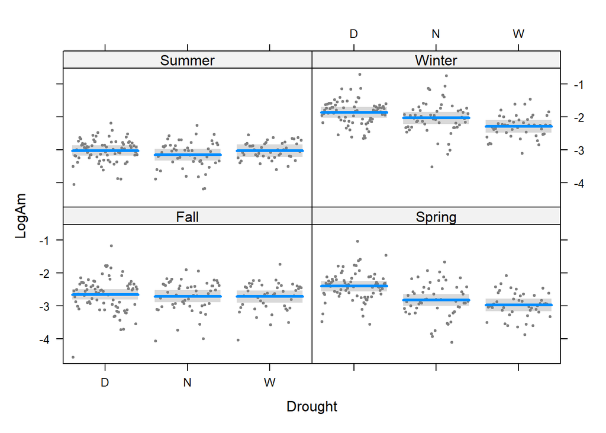

```r
visreg(Am1, xvar = "Drought", by = "Season")
```

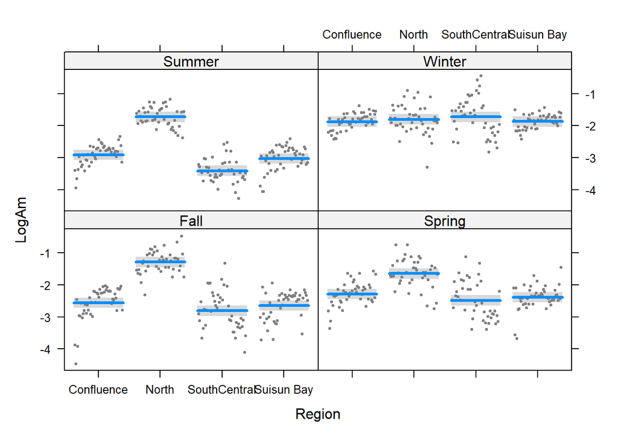

```r
visreg(Am1, xvar = "Region", by = "Season")
```

```
## I bet you wanted to call this with just object[[1]] - use '[[]]' or which' if I'm wrong.
## See '? emm_list' for more information
```

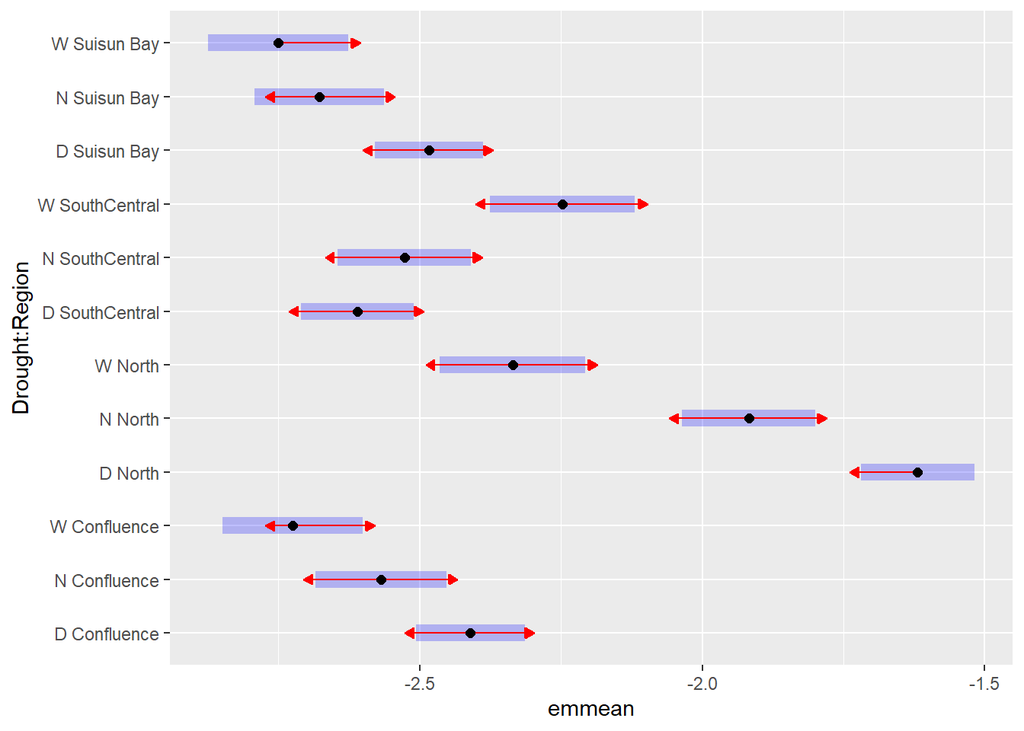

```r
amp = emmeans(Am1, pairwise ~ Drought*Region)
plot(amp, comparisons = T)
```

```
## I bet you wanted to call this with just object[[1]] - use '[[]]' or which' if I'm wrong.
## See '? emm_list' for more information
```

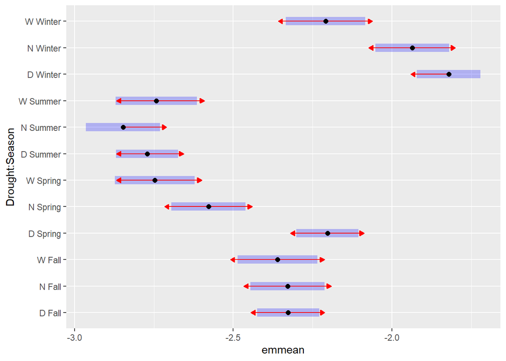

```r
ampx = emmeans(Am1, pairwise ~ Drought*Season)
plot(ampx, comparisons = T)
```

Now add the treatment plant term

```r
Am2 = lm(LogAm ~ Drought*Region+ Drought*Season + Region*Season + StocktonUpgrade, data = Ammonia)
summary(Am2)
```

```
##
## Call:
## lm(formula = LogAm ~ Drought * Region + Drought * Season + Region *
##     Season + StocktonUpgrade, data = Ammonia)
##
## Residuals:
##      Min       1Q   Median       3Q      Max
## -1.98811 -0.25424  0.02865  0.27453  1.39333
##
## Coefficients:
##                                 Estimate Std. Error t value Pr(>|t|)
## (Intercept)                     -2.63585    0.08166 -32.279  < 2e-16 ***
## DroughtN                        -0.04917    0.10063  -0.489 0.625284
## DroughtW                        -0.17815    0.10605  -1.680 0.093441 .
## RegionNorth                      1.27753    0.10557  12.101  < 2e-16 ***
## RegionSouthCentral              -0.24301    0.10557  -2.302 0.021652 *
## RegionSuisun Bay                -0.08490    0.10333  -0.822 0.411576
## SeasonSpring                     0.27580    0.10365   2.661 0.007980 **
## SeasonSummer                    -0.35668    0.10392  -3.432 0.000636 ***
## SeasonWinter                     0.68941    0.10514   6.557 1.10e-10 ***
## StocktonUpgradeBefore            0.15120    0.03702   4.084 4.96e-05 ***
## DroughtN:RegionNorth            -0.14581    0.10876  -1.341 0.180485
## DroughtW:RegionNorth            -0.40750    0.11391  -3.577 0.000372 ***
## DroughtN:RegionSouthCentral      0.23660    0.10876   2.175 0.029951 *
## DroughtW:RegionSouthCentral      0.67241    0.11391   5.903 5.70e-09 ***
## DroughtN:RegionSuisun Bay       -0.03715    0.10698  -0.347 0.728526
## DroughtW:RegionSuisun Bay        0.04791    0.11187   0.428 0.668618
## DroughtN:SeasonSpring           -0.37313    0.10841  -3.442 0.000614 ***
## DroughtW:SeasonSpring           -0.51036    0.11313  -4.511 7.63e-06 ***
## DroughtN:SeasonSummer           -0.07442    0.10841  -0.687 0.492633
## DroughtW:SeasonSummer            0.06272    0.11395   0.550 0.582197
## DroughtN:SeasonWinter           -0.11844    0.10873  -1.089 0.276396
## DroughtW:SeasonWinter           -0.35913    0.11374  -3.157 0.001664 **
## RegionNorth:SeasonSpring        -0.63246    0.12961  -4.880 1.33e-06 ***
## RegionSouthCentral:SeasonSpring  0.04837    0.12961   0.373 0.709115
## RegionSuisun Bay:SeasonSpring   -0.02334    0.12699  -0.184 0.854236
## RegionNorth:SeasonSummer        -0.07967    0.12997  -0.613 0.540069
## RegionSouthCentral:SeasonSummer -0.24778    0.12997  -1.906 0.057018 .
## RegionSuisun Bay:SeasonSummer   -0.02258    0.12772  -0.177 0.859725
## RegionNorth:SeasonWinter        -1.20649    0.12997  -9.283  < 2e-16 ***
## RegionSouthCentral:SeasonWinter  0.39710    0.12997   3.055 0.002338 **
## RegionSuisun Bay:SeasonWinter    0.09207    0.12809   0.719 0.472510
## ---
## Signif. codes:  0 '***' 0.001 '**' 0.01 '*' 0.05 '.' 0.1 ' ' 1
##
## Residual standard error: 0.4282 on 664 degrees of freedom
##   (41 observations deleted due to missingness)
## Multiple R-squared:  0.6163, Adjusted R-squared:  0.599
## F-statistic: 35.55 on 30 and 664 DF,  p-value: < 2.2e-16
```

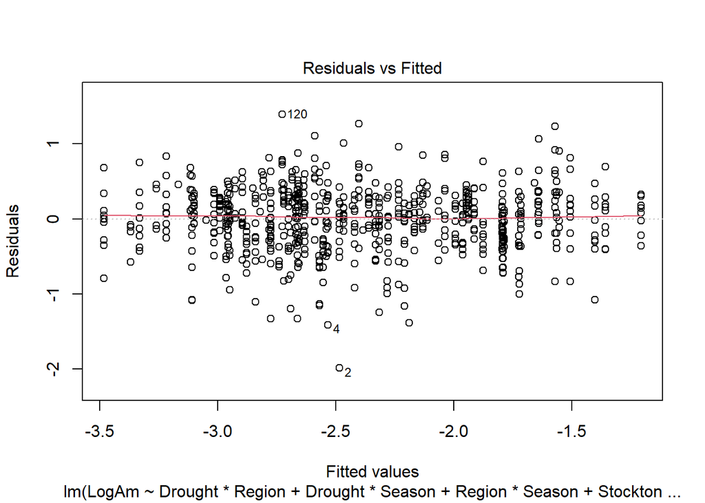

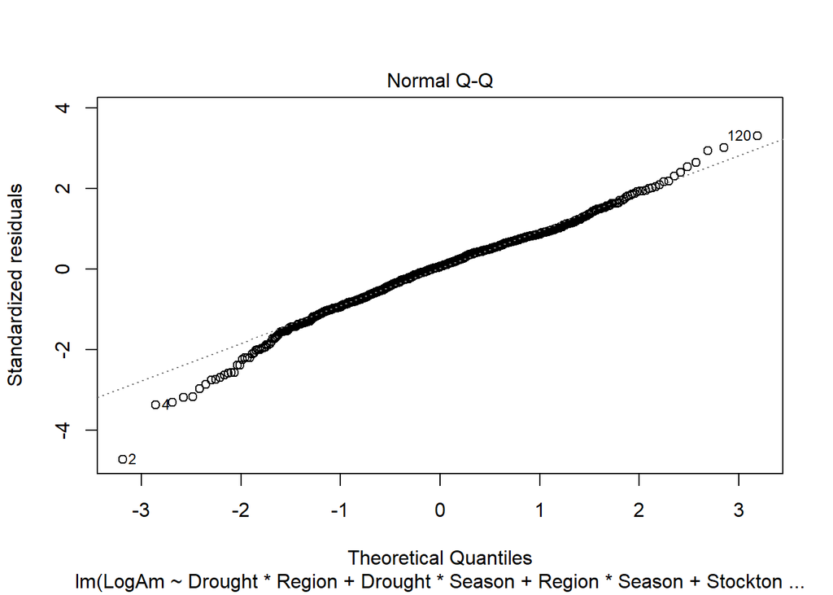

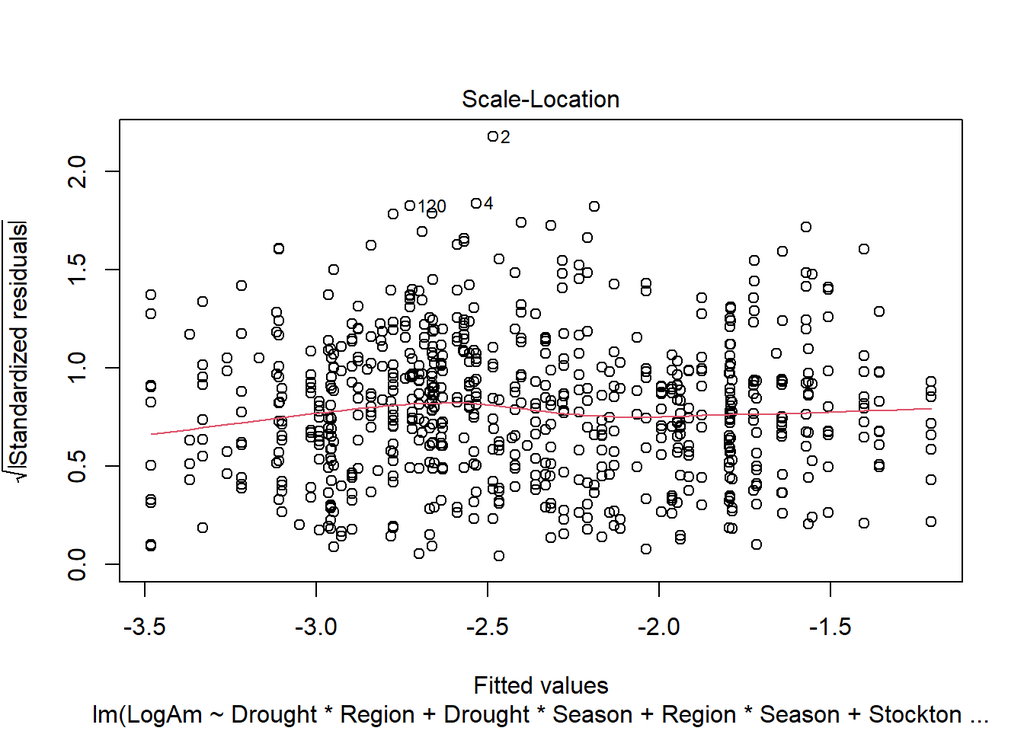

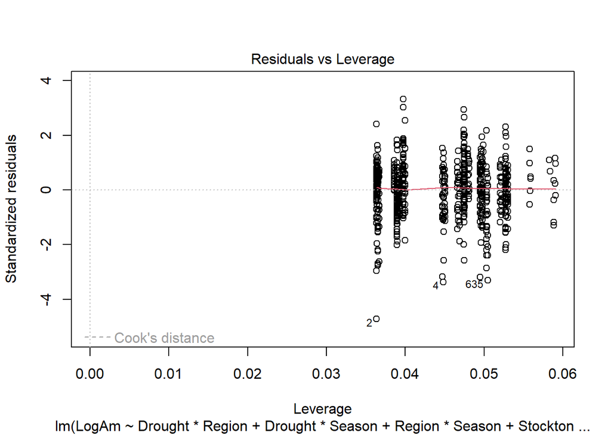

```r
plot(Am2)
```

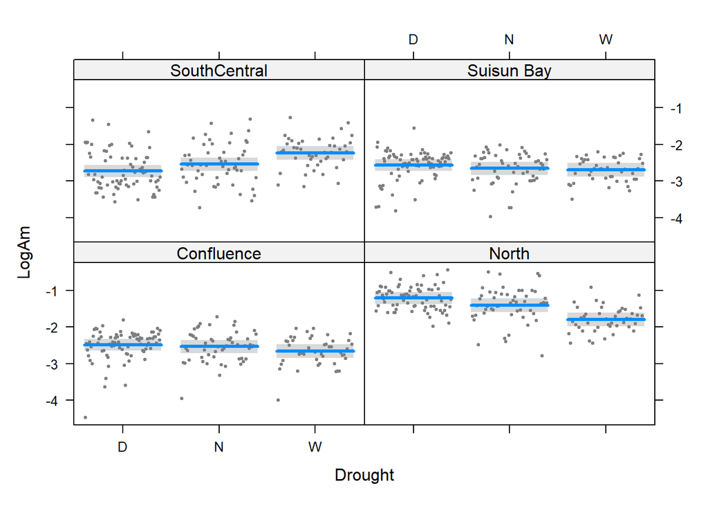

```r
visreg(Am2, xvar = "Drought", by = "Region")
```

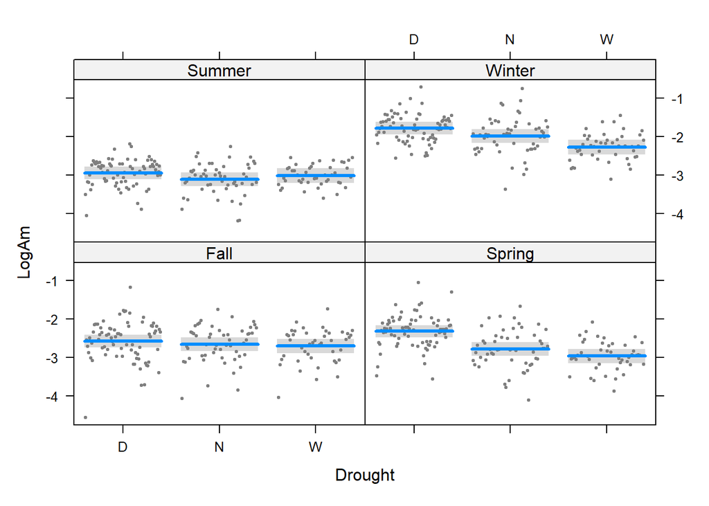

```r
visreg(Am2, xvar = "Drought", by = "Season")
```

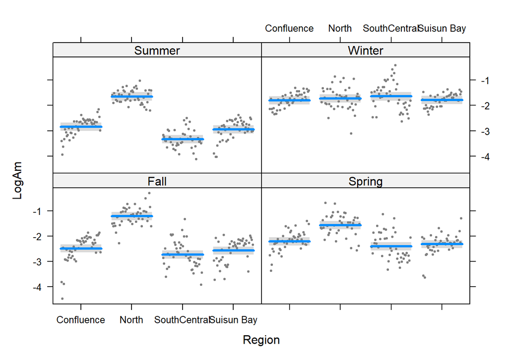

```r
visreg(Am2, xvar = "Region", by = "Season")
```

```
## I bet you wanted to call this with just object[[1]] - use '[[]]' or which' if I'm wrong.
## See '? emm_list' for more information
```

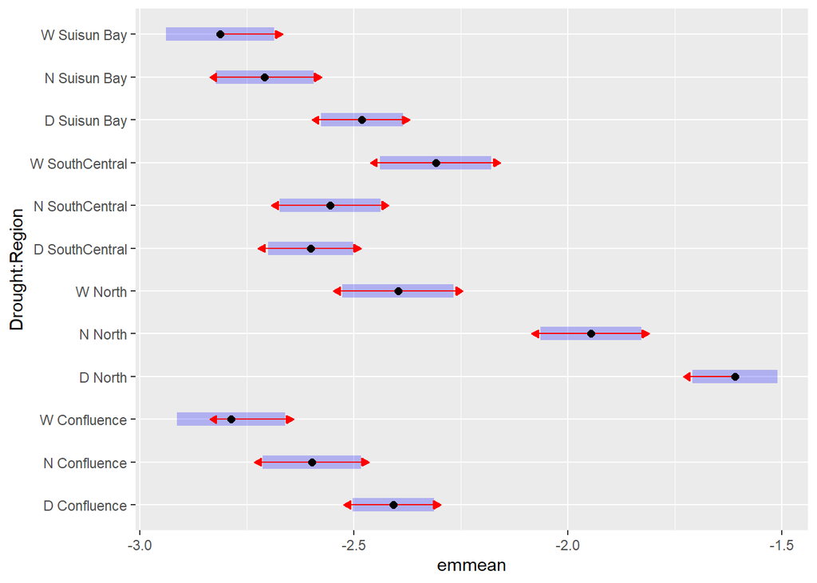

```r
amp2 = emmeans(Am2, pairwise ~ Drought*Region)
plot(amp2, comparisons = T)
```

```
## I bet you wanted to call this with just object[[1]] - use '[[]]' or which' if I'm wrong.
## See '? emm_list' for more information
```

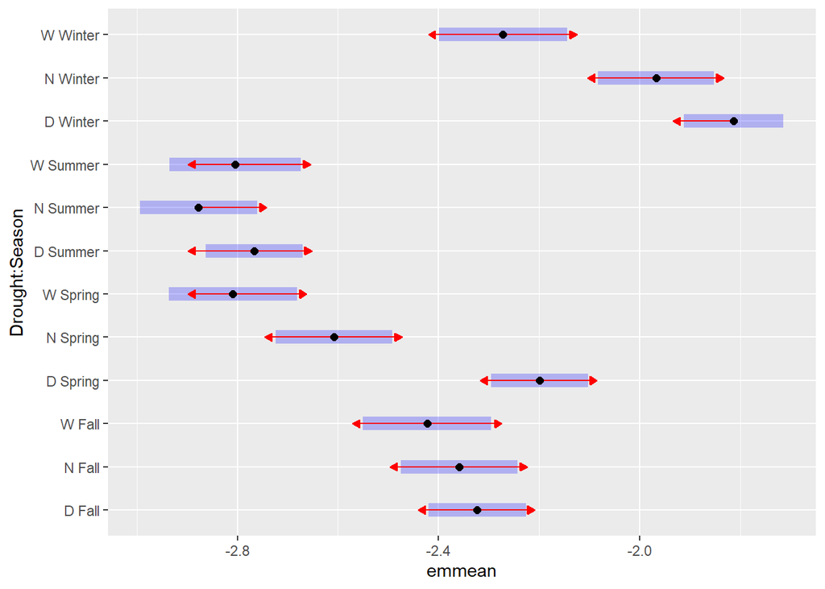

```r
amp2x = emmeans(Am2, pairwise ~ Drought*Season)
plot(amp2x, comparisons = T)
```

```r
AIC(Am2)
```

```
## [1] 825.7783
```

```r
AIC(Am1)
```

```
## [1] 841.0231
```

Well, the treatment plant term improves the model a bit, but it doesn’t actually change hte drought story. However includeing the region*season interaction and taking out 2021 does make this a little more interesting than before. Droughts in the north are definitely higher in Ammonia.

## Now do nitrate

```r
#replace values below the reporting limit
Nitrate <- raw_nutr_1975_2021 %>%
  # Remove NA values in DissNitrate
  tidyr::drop_na(DissNitrateNitrite) %>%
  # Replace <RL values with random value
  drt_replace_rl(DissNitrateNitrite, DissNitrateNitrite_Sign) %>%
  # Calculate seasonal-regional averages
  drt_avg_data(DissNitrateNitrite, avg_type = "both", month_na = "relaxed") %>%
  # Add year assignments
  drt_add_yr_assign() %>%
  mutate(YearType = factor(YearType, levels = c("Critical", "Dry", "Below Normal",
                                                "Above Normal", "Wet")),
         LogNat = log(DissNitrateNitrite))
```

Exploritory plots

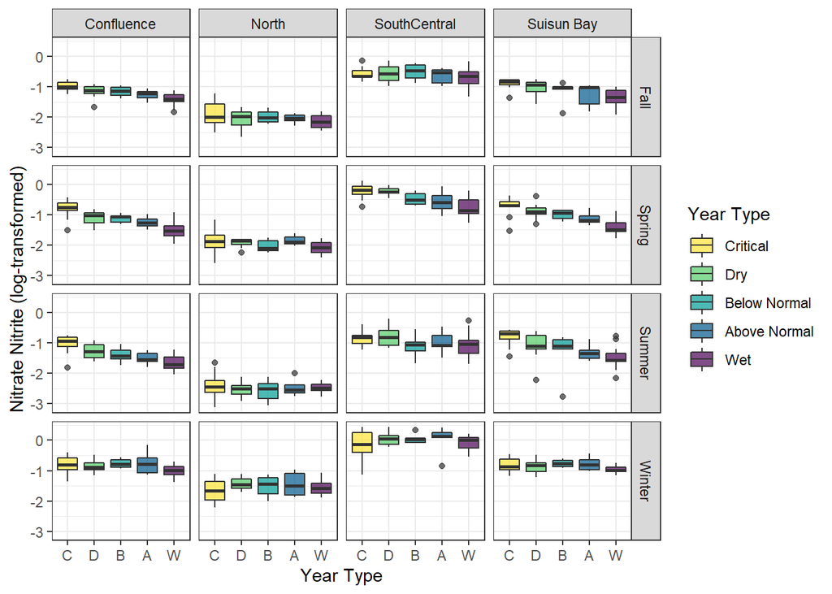

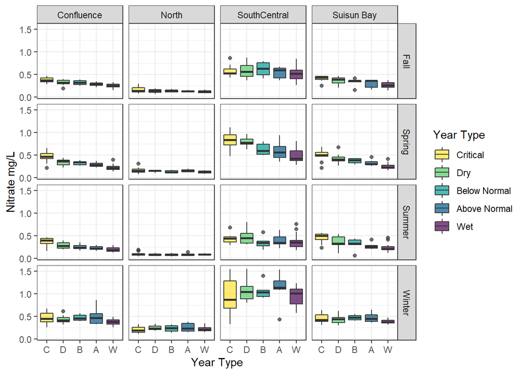

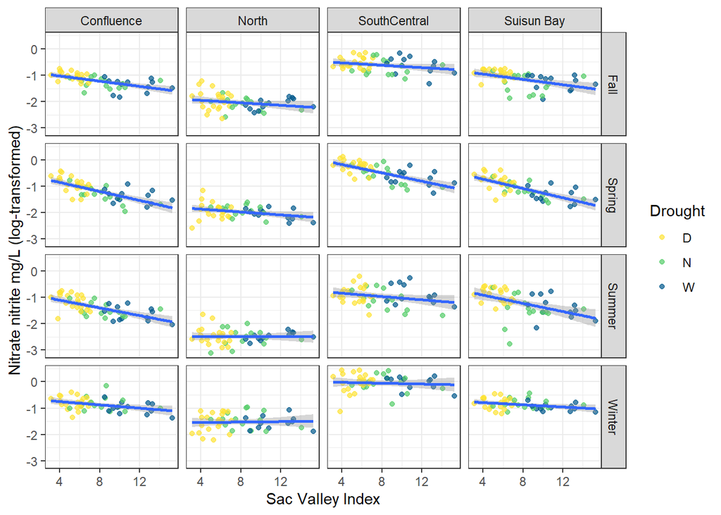

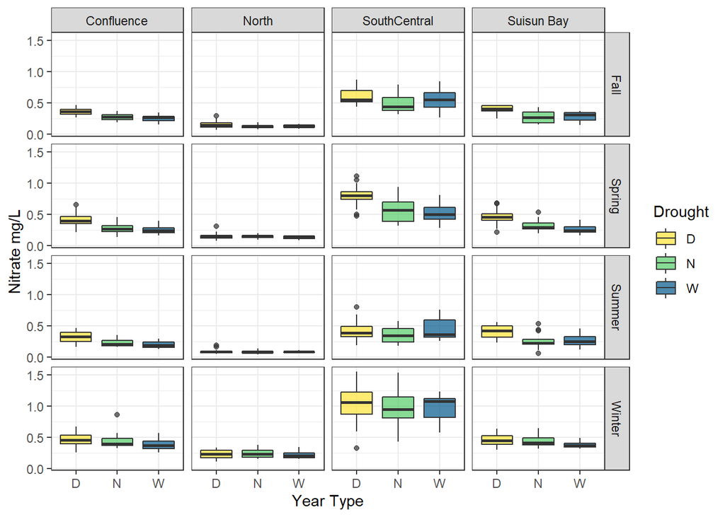

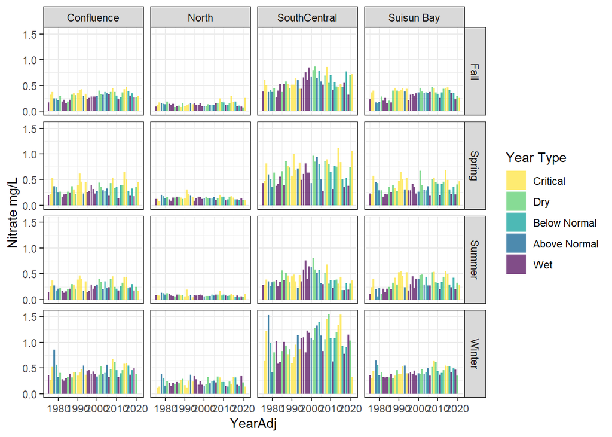

OK, now for the statistics. The treatment plant upgrades didn’t have as big an impact on nitrate, so I’ll leave it out for now, but I can put it back in if folks think it’s important.

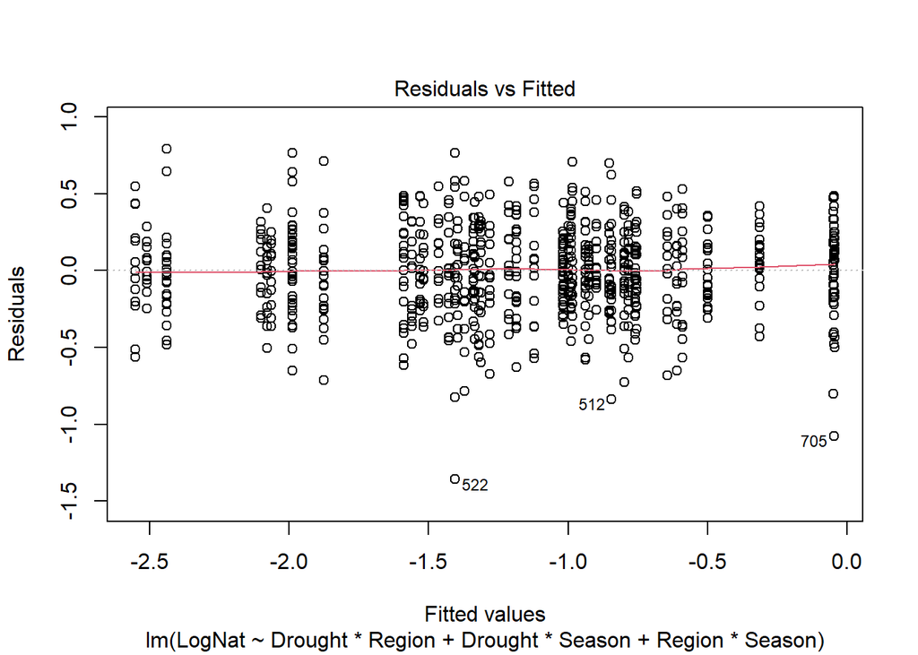

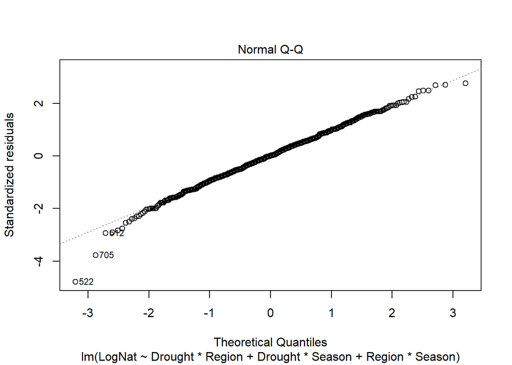

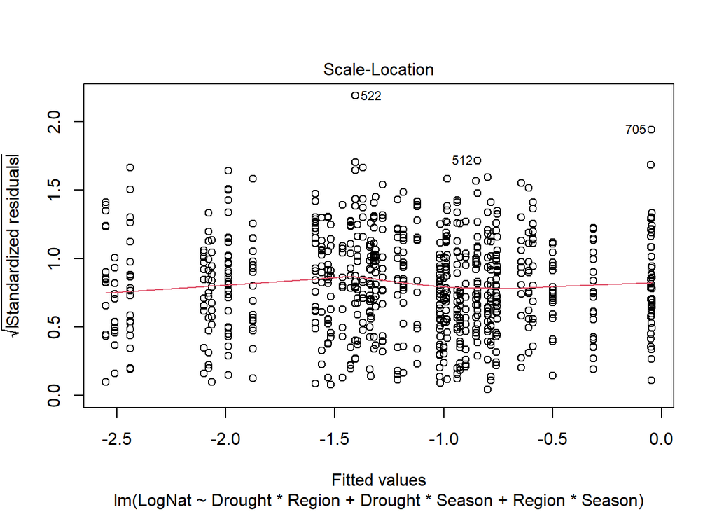

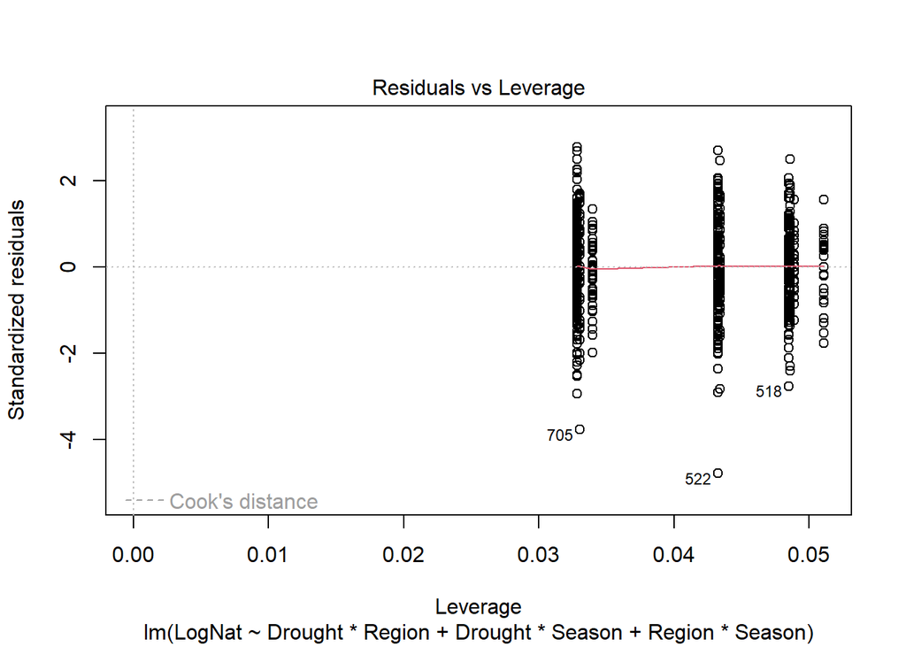

```r
Nat2 = lm(LogNat ~Drought*Region + Drought*Season + Region*Season, data = Nitrate)
plot(Nat2)
```